# (Prosper loan data Exploration Title)

## Preliminary Wrangling

```python
# import all packages and set plots to be embedded inline
import numpy as np
import pandas as pd
import matplotlib.pyplot as plt
import seaborn as sb

%matplotlib inline
```

> Load in your dataset and describe its properties through the questions below. Try and motivate your exploration goals through this section.

```python
df2 = pd.read_csv('prosperLoanData.csv')
df2.head(10)
```

|  | ListingKey | ListingNumber | ListingCreationDate | CreditGrade | Term | LoanStatus | ClosedDate | BorrowerAPR | BorrowerRate | LenderYield | ... | LP_ServiceFees | LP_CollectionFees | LP_GrossPrincipalLoss | LP_NetPrincipalLoss | LP_NonPrincipalRecoverypayments | PercentFunded | Recommendations | InvestmentFromFriendsCount | InvestmentFromFriendsAmount | Investors |
| --- | --- | --- | --- | --- | --- | --- | --- | --- | --- | --- | --- | --- | --- | --- | --- | --- | --- | --- | --- | --- | --- |
| 0 | 1021339766868145413AB3B | 193129 | 2007-08-26 19:09:29.263000000 | C | 36 | Completed | 2009-08-14 00:00:00 | 0.16516 | 0.1580 | 0.1380 | ... | -133.18 | 0.0 | 0.0 | 0.0 | 0.0 | 1.0 | 0 | 0 | 0.0 | 258 |
| 1 | 10273602499503308B223C1 | 1209647 | 2014-02-27 08:28:07.900000000 | NaN | 36 | Current | NaN | 0.12016 | 0.0920 | 0.0820 | ... | 0.00 | 0.0 | 0.0 | 0.0 | 0.0 | 1.0 | 0 | 0 | 0.0 | 1 |
| 2 | 0EE9337825851032864889A | 81716 | 2007-01-05 15:00:47.090000000 | HR | 36 | Completed | 2009-12-17 00:00:00 | 0.28269 | 0.2750 | 0.2400 | ... | -24.20 | 0.0 | 0.0 | 0.0 | 0.0 | 1.0 | 0 | 0 | 0.0 | 41 |
| 3 | 0EF5356002482715299901A | 658116 | 2012-10-22 11:02:35.010000000 | NaN | 36 | Current | NaN | 0.12528 | 0.0974 | 0.0874 | ... | -108.01 | 0.0 | 0.0 | 0.0 | 0.0 | 1.0 | 0 | 0 | 0.0 | 158 |
| 4 | 0F023589499656230C5E3E2 | 909464 | 2013-09-14 18:38:39.097000000 | NaN | 36 | Current | NaN | 0.24614 | 0.2085 | 0.1985 | ... | -60.27 | 0.0 | 0.0 | 0.0 | 0.0 | 1.0 | 0 | 0 | 0.0 | 20 |
| 5 | 0F05359734824199381F61D | 1074836 | 2013-12-14 08:26:37.093000000 | NaN | 60 | Current | NaN | 0.15425 | 0.1314 | 0.1214 | ... | -25.33 | 0.0 | 0.0 | 0.0 | 0.0 | 1.0 | 0 | 0 | 0.0 | 1 |
| 6 | 0F0A3576754255009D63151 | 750899 | 2013-04-12 09:52:56.147000000 | NaN | 36 | Current | NaN | 0.31032 | 0.2712 | 0.2612 | ... | -22.95 | 0.0 | 0.0 | 0.0 | 0.0 | 1.0 | 0 | 0 | 0.0 | 1 |
| 7 | 0F1035772717087366F9EA7 | 768193 | 2013-05-05 06:49:27.493000000 | NaN | 36 | Current | NaN | 0.23939 | 0.2019 | 0.1919 | ... | -69.21 | 0.0 | 0.0 | 0.0 | 0.0 | 1.0 | 0 | 0 | 0.0 | 1 |
| 8 | 0F043596202561788EA13D5 | 1023355 | 2013-12-02 10:43:39.117000000 | NaN | 36 | Current | NaN | 0.07620 | 0.0629 | 0.0529 | ... | -16.77 | 0.0 | 0.0 | 0.0 | 0.0 | 1.0 | 0 | 0 | 0.0 | 1 |
| 9 | 0F043596202561788EA13D5 | 1023355 | 2013-12-02 10:43:39.117000000 | NaN | 36 | Current | NaN | 0.07620 | 0.0629 | 0.0529 | ... | -16.77 | 0.0 | 0.0 | 0.0 | 0.0 | 1.0 | 0 | 0 | 0.0 | 1 |

10 rows × 81 columns

```python
df2.EmploymentStatus.unique()
```

```
array(['Self-employed', 'Employed', 'Not available', 'Full-time', 'Other',
       nan, 'Not employed', 'Part-time', 'Retired'], dtype=object)
```

```python
df = df2[df2['ListingCreationDate']>='2009-07-01']
df.head()
```

|  | ListingKey | ListingNumber | ListingCreationDate | CreditGrade | Term | LoanStatus | ClosedDate | BorrowerAPR | BorrowerRate | LenderYield | ... | LP_ServiceFees | LP_CollectionFees | LP_GrossPrincipalLoss | LP_NetPrincipalLoss | LP_NonPrincipalRecoverypayments | PercentFunded | Recommendations | InvestmentFromFriendsCount | InvestmentFromFriendsAmount | Investors |
| --- | --- | --- | --- | --- | --- | --- | --- | --- | --- | --- | --- | --- | --- | --- | --- | --- | --- | --- | --- | --- | --- |
| 1 | 10273602499503308B223C1 | 1209647 | 2014-02-27 08:28:07.900000000 | NaN | 36 | Current | NaN | 0.12016 | 0.0920 | 0.0820 | ... | 0.00 | 0.0 | 0.0 | 0.0 | 0.0 | 1.0 | 0 | 0 | 0.0 | 1 |
| 3 | 0EF5356002482715299901A | 658116 | 2012-10-22 11:02:35.010000000 | NaN | 36 | Current | NaN | 0.12528 | 0.0974 | 0.0874 | ... | -108.01 | 0.0 | 0.0 | 0.0 | 0.0 | 1.0 | 0 | 0 | 0.0 | 158 |
| 4 | 0F023589499656230C5E3E2 | 909464 | 2013-09-14 18:38:39.097000000 | NaN | 36 | Current | NaN | 0.24614 | 0.2085 | 0.1985 | ... | -60.27 | 0.0 | 0.0 | 0.0 | 0.0 | 1.0 | 0 | 0 | 0.0 | 20 |
| 5 | 0F05359734824199381F61D | 1074836 | 2013-12-14 08:26:37.093000000 | NaN | 60 | Current | NaN | 0.15425 | 0.1314 | 0.1214 | ... | -25.33 | 0.0 | 0.0 | 0.0 | 0.0 | 1.0 | 0 | 0 | 0.0 | 1 |
| 6 | 0F0A3576754255009D63151 | 750899 | 2013-04-12 09:52:56.147000000 | NaN | 36 | Current | NaN | 0.31032 | 0.2712 | 0.2612 | ... | -22.95 | 0.0 | 0.0 | 0.0 | 0.0 | 1.0 | 0 | 0 | 0.0 | 1 |

5 rows × 81 columns

```python
df.LoanStatus.unique()
```

```
array(['Current', 'Past Due (1-15 days)', 'Defaulted', 'Completed',
       'Chargedoff', 'Past Due (16-30 days)', 'Past Due (61-90 days)',
       'Past Due (31-60 days)', 'Past Due (91-120 days)',
       'FinalPaymentInProgress', 'Past Due (>120 days)'], dtype=object)
```

```python
df.IncomeRange.unique()
```

```
array(['$50,000-74,999', '$25,000-49,999', '$100,000+', '$75,000-99,999',
       '$1-24,999', 'Not employed', '$0'], dtype=object)
```

```python
df2.columns
```

```
Index(['ListingKey', 'ListingNumber', 'ListingCreationDate', 'CreditGrade',
       'Term', 'LoanStatus', 'ClosedDate', 'BorrowerAPR', 'BorrowerRate',
       'LenderYield', 'EstimatedEffectiveYield', 'EstimatedLoss',
       'EstimatedReturn', 'ProsperRating (numeric)', 'ProsperRating (Alpha)',
       'ProsperScore', 'ListingCategory (numeric)', 'BorrowerState',
       'Occupation', 'EmploymentStatus', 'EmploymentStatusDuration',
       'IsBorrowerHomeowner', 'CurrentlyInGroup', 'GroupKey',
       'DateCreditPulled', 'CreditScoreRangeLower', 'CreditScoreRangeUpper',
       'FirstRecordedCreditLine', 'CurrentCreditLines', 'OpenCreditLines',
       'TotalCreditLinespast7years', 'OpenRevolvingAccounts',
       'OpenRevolvingMonthlyPayment', 'InquiriesLast6Months', 'TotalInquiries',
       'CurrentDelinquencies', 'AmountDelinquent', 'DelinquenciesLast7Years',
       'PublicRecordsLast10Years', 'PublicRecordsLast12Months',
       'RevolvingCreditBalance', 'BankcardUtilization',
       'AvailableBankcardCredit', 'TotalTrades',
       'TradesNeverDelinquent (percentage)', 'TradesOpenedLast6Months',
       'DebtToIncomeRatio', 'IncomeRange', 'IncomeVerifiable',
       'StatedMonthlyIncome', 'LoanKey', 'TotalProsperLoans',
       'TotalProsperPaymentsBilled', 'OnTimeProsperPayments',
       'ProsperPaymentsLessThanOneMonthLate',
       'ProsperPaymentsOneMonthPlusLate', 'ProsperPrincipalBorrowed',
       'ProsperPrincipalOutstanding', 'ScorexChangeAtTimeOfListing',
       'LoanCurrentDaysDelinquent', 'LoanFirstDefaultedCycleNumber',
       'LoanMonthsSinceOrigination', 'LoanNumber', 'LoanOriginalAmount',
       'LoanOriginationDate', 'LoanOriginationQuarter', 'MemberKey',
       'MonthlyLoanPayment', 'LP_CustomerPayments',
       'LP_CustomerPrincipalPayments', 'LP_InterestandFees', 'LP_ServiceFees',
       'LP_CollectionFees', 'LP_GrossPrincipalLoss', 'LP_NetPrincipalLoss',
       'LP_NonPrincipalRecoverypayments', 'PercentFunded', 'Recommendations',
       'InvestmentFromFriendsCount', 'InvestmentFromFriendsAmount',
       'Investors'],
      dtype='object')
```

```python
df['ListingCategory (numeric)'].value_counts()
```

```
1     53180
7      9218
2      6801
3      5298
6      2237
13     1996
15     1522
18      885
14      876
20      771
19      768
16      304
5       274
11      217
8       199
10       91
9        85
12       59
17       52
0        20
Name: ListingCategory (numeric), dtype: int64
```

```python
ordinal_var_dict = {'EmploymentStatus': ['Employed', 'Other', 'Full-time', 'Self-employed', 'Not employed',
       'Retired', 'Part-time'],
                    'LoanStatus': ['Current', 'Past Due (1-15 days)', 'Defaulted', 'Completed',
       'Chargedoff', 'Past Due (16-30 days)', 'Past Due (61-90 days)',
       'Past Due (31-60 days)', 'Past Due (91-120 days)',
       'FinalPaymentInProgress', 'Past Due (>120 days)'],'IncomeRange':['$50,000-74,999', '$25,000-49,999', '$100,000+', '$75,000-99,999',
       '$1-24,999', 'Not employed', '$0']
                    }

for var in ordinal_var_dict:
    ordered_var = pd.api.types.CategoricalDtype(ordered = True,
                                                categories = ordinal_var_dict[var])
    df[var] = df[var].astype(ordered_var)
```

```python
df.describe()
```

|  | ListingNumber | Term | BorrowerAPR | BorrowerRate | LenderYield | EstimatedEffectiveYield | EstimatedLoss | EstimatedReturn | ProsperRating (numeric) | ProsperScore | ... | LP_ServiceFees | LP_CollectionFees | LP_GrossPrincipalLoss | LP_NetPrincipalLoss | LP_NonPrincipalRecoverypayments | PercentFunded | Recommendations | InvestmentFromFriendsCount | InvestmentFromFriendsAmount | Investors |
| --- | --- | --- | --- | --- | --- | --- | --- | --- | --- | --- | --- | --- | --- | --- | --- | --- | --- | --- | --- | --- | --- |
| count | 8.485300e+04 | 84853.000000 | 84853.000000 | 84853.000000 | 84853.000000 | 84853.000000 | 84853.000000 | 84853.000000 | 84853.000000 | 84853.000000 | ... | 84853.000000 | 84853.000000 | 84853.000000 | 84853.000000 | 84853.000000 | 84853.000000 | 84853.000000 | 84853.000000 | 84853.000000 | 84853.000000 |
| mean | 7.738749e+05 | 42.486135 | 0.226658 | 0.196022 | 0.186017 | 0.168661 | 0.080306 | 0.096068 | 4.072243 | 5.950067 | ... | -54.642104 | -8.206068 | 376.088798 | 367.724881 | 7.647064 | 0.998098 | 0.017560 | 0.008049 | 4.315558 | 68.264669 |
| std | 2.363387e+05 | 11.640346 | 0.079916 | 0.074631 | 0.074631 | 0.068467 | 0.046764 | 0.030403 | 1.673227 | 2.376501 | ... | 59.729078 | 75.185535 | 1720.769115 | 1700.211129 | 119.165278 | 0.020742 | 0.187963 | 0.109721 | 117.005989 | 95.195831 |
| min | 4.162750e+05 | 12.000000 | 0.045830 | 0.040000 | 0.030000 | -0.182700 | 0.004900 | -0.182700 | 1.000000 | 1.000000 | ... | -589.950000 | -4865.080000 | -94.200000 | -504.410000 | 0.000000 | 0.700000 | 0.000000 | 0.000000 | 0.000000 | 1.000000 |
| 25% | 5.580860e+05 | 36.000000 | 0.163280 | 0.135900 | 0.125900 | 0.115670 | 0.042400 | 0.074080 | 3.000000 | 4.000000 | ... | -72.300000 | 0.000000 | 0.000000 | 0.000000 | 0.000000 | 1.000000 | 0.000000 | 0.000000 | 0.000000 | 1.000000 |
| 50% | 7.392460e+05 | 36.000000 | 0.219450 | 0.187500 | 0.177500 | 0.161500 | 0.072400 | 0.091700 | 4.000000 | 6.000000 | ... | -34.900000 | 0.000000 | 0.000000 | 0.000000 | 0.000000 | 1.000000 | 0.000000 | 0.000000 | 0.000000 | 32.000000 |
| 75% | 9.794360e+05 | 60.000000 | 0.292540 | 0.257400 | 0.247400 | 0.224300 | 0.112000 | 0.116600 | 5.000000 | 8.000000 | ... | -14.280000 | 0.000000 | 0.000000 | 0.000000 | 0.000000 | 1.000000 | 0.000000 | 0.000000 | 0.000000 | 97.000000 |
| max | 1.255725e+06 | 60.000000 | 0.423950 | 0.360000 | 0.340000 | 0.319900 | 0.366000 | 0.283700 | 7.000000 | 11.000000 | ... | 3.010000 | 0.000000 | 25000.000000 | 25000.000000 | 7780.030000 | 1.012500 | 19.000000 | 9.000000 | 11000.000000 | 1189.000000 |

8 rows × 61 columns

```python
df.LoanStatus.dtypes
```

```
CategoricalDtype(categories=['Current', 'Past Due (1-15 days)', 'Defaulted', 'Completed',
                  'Chargedoff', 'Past Due (16-30 days)',
                  'Past Due (61-90 days)', 'Past Due (31-60 days)',
                  'Past Due (91-120 days)', 'FinalPaymentInProgress',
                  'Past Due (>120 days)'],
                 ordered=True)
```

```python
df.iloc[:,13:39]
```

|  | ProsperRating (numeric) | ProsperRating (Alpha) | ProsperScore | ListingCategory (numeric) | BorrowerState | Occupation | EmploymentStatus | EmploymentStatusDuration | IsBorrowerHomeowner | CurrentlyInGroup | ... | OpenCreditLines | TotalCreditLinespast7years | OpenRevolvingAccounts | OpenRevolvingMonthlyPayment | InquiriesLast6Months | TotalInquiries | CurrentDelinquencies | AmountDelinquent | DelinquenciesLast7Years | PublicRecordsLast10Years |
| --- | --- | --- | --- | --- | --- | --- | --- | --- | --- | --- | --- | --- | --- | --- | --- | --- | --- | --- | --- | --- | --- |
| 1 | 6.0 | A | 7.0 | 2 | CO | Professional | Employed | 44.0 | False | False | ... | 14.0 | 29.0 | 13 | 389.0 | 3.0 | 5.0 | 0.0 | 0.0 | 0.0 | 1.0 |
| 3 | 6.0 | A | 9.0 | 16 | GA | Skilled Labor | Employed | 113.0 | True | False | ... | 5.0 | 29.0 | 7 | 115.0 | 0.0 | 1.0 | 4.0 | 10056.0 | 14.0 | 0.0 |
| 4 | 3.0 | D | 4.0 | 2 | MN | Executive | Employed | 44.0 | True | False | ... | 19.0 | 49.0 | 6 | 220.0 | 1.0 | 9.0 | 0.0 | 0.0 | 0.0 | 0.0 |
| 5 | 5.0 | B | 10.0 | 1 | NM | Professional | Employed | 82.0 | True | False | ... | 17.0 | 49.0 | 13 | 1410.0 | 0.0 | 2.0 | 0.0 | 0.0 | 0.0 | 0.0 |
| 6 | 2.0 | E | 2.0 | 1 | KS | Sales - Retail | Employed | 172.0 | False | False | ... | 7.0 | 20.0 | 6 | 214.0 | 0.0 | 0.0 | 0.0 | 0.0 | 0.0 | 0.0 |
| ... | ... | ... | ... | ... | ... | ... | ... | ... | ... | ... | ... | ... | ... | ... | ... | ... | ... | ... | ... | ... | ... |
| 113932 | 4.0 | C | 5.0 | 1 | IL | Food Service Management | Employed | 246.0 | True | False | ... | 9.0 | 41.0 | 9 | 209.0 | 0.0 | 0.0 | 0.0 | 0.0 | 7.0 | 1.0 |
| 113933 | 6.0 | A | 8.0 | 7 | PA | Professional | Employed | 21.0 | True | False | ... | 13.0 | 39.0 | 9 | 495.0 | 1.0 | 4.0 | 1.0 | 5062.0 | 4.0 | 0.0 |
| 113934 | 3.0 | D | 3.0 | 1 | TX | Other | Employed | 84.0 | True | False | ... | 12.0 | 25.0 | 9 | 521.0 | 1.0 | 2.0 | 0.0 | 0.0 | 0.0 | 0.0 |
| 113935 | 4.0 | C | 5.0 | 2 | GA | Food Service | Full-time | 94.0 | True | False | ... | 11.0 | 22.0 | 7 | 488.0 | 1.0 | 4.0 | 0.0 | 0.0 | 0.0 | 1.0 |
| 113936 | 6.0 | A | 7.0 | 1 | NY | Professor | Employed | 244.0 | False | False | ... | 9.0 | 44.0 | 8 | 289.0 | 0.0 | 1.0 | 1.0 | 257.0 | 3.0 | 1.0 |

84853 rows × 26 columns

```python
df['LoanStatus'].unique()
```

```
[Current, Past Due (1-15 days), Defaulted, Completed, Chargedoff, ..., Past Due (61-90 days), Past Due (31-60 days), Past Due (91-120 days), FinalPaymentInProgress, Past Due (>120 days)]
Length: 11
Categories (11, object): [Current < Past Due (1-15 days) < Defaulted < Completed ... Past Due (31-60 days) < Past Due (91-120 days) < FinalPaymentInProgress < Past Due (>120 days)]
```

```python
df.shape
```

```
(84853, 81)
```

### What is the structure of your dataset?

the dataframe at the first (before cleaning or indexing it ) contains 113937 rows with 81 columns, each row is about a loan, most variables are numeric but there are some data that seems to be categorical like prosper rating numeric , prosper rating (alpha) 7 , prosperscore 11 unique value , employment status , Isborrowerhomeowner,currently in group , also I observed that many colums say that the date is after 2009 so I dropped all the entries that is before 2009 after this modification the data became 84853 entries or rows

### What is/are the main feature(s) of interest in your dataset?

> my main interest here is LoanStatus,borrowerAPR,Borrowerrate and how they are affected by the other variables that I am going to investigate

### What features in the dataset do you think will help support your investigation into your feature(s) of interest?

> my initial intuition that the features that I will need to investigate is ProsperRating (numeric),ProsperRating (Alpha),ProsperScore,CurrentlyIngroup,EmploymentStatus,EmploymentStatusDuration,IsBorrowerHomeowner,CurrentDelinquencies,DebtToIncomeRatio

```python
df['LoanOriginalAmount'].value_counts()
```

```
4000     13233
15000    11460
10000     9816
2000      4591
5000      4224
         ...
19950        1
1575         1
5733         1
11938        1
8196         1
Name: LoanOriginalAmount, Length: 1934, dtype: int64
```

```python
df.iloc[:,60:80]
```

|  | LoanFirstDefaultedCycleNumber | LoanMonthsSinceOrigination | LoanNumber | LoanOriginalAmount | LoanOriginationDate | LoanOriginationQuarter | MemberKey | MonthlyLoanPayment | LP_CustomerPayments | LP_CustomerPrincipalPayments | LP_InterestandFees | LP_ServiceFees | LP_CollectionFees | LP_GrossPrincipalLoss | LP_NetPrincipalLoss | LP_NonPrincipalRecoverypayments | PercentFunded | Recommendations | InvestmentFromFriendsCount | InvestmentFromFriendsAmount |
| --- | --- | --- | --- | --- | --- | --- | --- | --- | --- | --- | --- | --- | --- | --- | --- | --- | --- | --- | --- | --- |
| 1 | NaN | 0 | 134815 | 10000 | 2014-03-03 00:00:00 | Q1 2014 | 1D13370546739025387B2F4 | 318.93 | 0.0000 | 0.00 | 0.0000 | 0.00 | 0.0 | 0.0 | 0.0 | 0.0 | 1.0 | 0 | 0 | 0.0 |
| 3 | NaN | 16 | 77296 | 10000 | 2012-11-01 00:00:00 | Q4 2012 | 9ADE356069835475068C6D2 | 321.45 | 5143.2000 | 4091.09 | 1052.1100 | -108.01 | 0.0 | 0.0 | 0.0 | 0.0 | 1.0 | 0 | 0 | 0.0 |
| 4 | NaN | 6 | 102670 | 15000 | 2013-09-20 00:00:00 | Q3 2013 | 36CE356043264555721F06C | 563.97 | 2819.8500 | 1563.22 | 1256.6300 | -60.27 | 0.0 | 0.0 | 0.0 | 0.0 | 1.0 | 0 | 0 | 0.0 |
| 5 | NaN | 3 | 123257 | 15000 | 2013-12-24 00:00:00 | Q4 2013 | 874A3701157341738DE458F | 342.37 | 679.3400 | 351.89 | 327.4500 | -25.33 | 0.0 | 0.0 | 0.0 | 0.0 | 1.0 | 0 | 0 | 0.0 |
| 6 | NaN | 11 | 88353 | 3000 | 2013-04-18 00:00:00 | Q2 2013 | AA4535764146102879D5959 | 122.67 | 1226.7000 | 604.25 | 622.4500 | -22.95 | 0.0 | 0.0 | 0.0 | 0.0 | 1.0 | 0 | 0 | 0.0 |
| ... | ... | ... | ... | ... | ... | ... | ... | ... | ... | ... | ... | ... | ... | ... | ... | ... | ... | ... | ... | ... |
| 113932 | NaN | 11 | 88485 | 10000 | 2013-04-22 00:00:00 | Q2 2013 | 2EC435768441332602FDC15 | 364.74 | 3647.4000 | 2238.38 | 1409.0200 | -75.58 | 0.0 | 0.0 | 0.0 | 0.0 | 1.0 | 0 | 0 | 0.0 |
| 113933 | NaN | 28 | 55801 | 2000 | 2011-11-07 00:00:00 | Q4 2011 | 55C4336679182766893E4FC | 65.57 | 2330.5500 | 1997.16 | 333.3900 | -30.05 | 0.0 | 0.0 | 0.0 | 0.0 | 1.0 | 0 | 0 | 0.0 |
| 113934 | NaN | 3 | 123122 | 10000 | 2013-12-23 00:00:00 | Q4 2013 | 0FE0370029359765342FDB5 | 273.35 | 546.7000 | 183.15 | 363.5500 | -16.91 | 0.0 | 0.0 | 0.0 | 0.0 | 1.0 | 0 | 0 | 0.0 |
| 113935 | NaN | 28 | 56401 | 15000 | 2011-11-21 00:00:00 | Q4 2011 | A33834861822272782621C8 | 449.55 | 21122.5600 | 15000.00 | 6122.5600 | -235.05 | 0.0 | 0.0 | 0.0 | 0.0 | 1.0 | 0 | 0 | 0.0 |
| 113936 | NaN | 2 | 127508 | 2000 | 2014-01-21 00:00:00 | Q1 2014 | CE1E3704648000761C9F724 | 64.90 | 64.3307 | 47.25 | 17.0807 | -1.70 | 0.0 | 0.0 | 0.0 | 0.0 | 1.0 | 0 | 0 | 0.0 |

84853 rows × 20 columns

```python
df[df['LoanOriginalAmount']<1000]
```

|  | ListingKey | ListingNumber | ListingCreationDate | CreditGrade | Term | LoanStatus | ClosedDate | BorrowerAPR | BorrowerRate | LenderYield | ... | LP_ServiceFees | LP_CollectionFees | LP_GrossPrincipalLoss | LP_NetPrincipalLoss | LP_NonPrincipalRecoverypayments | PercentFunded | Recommendations | InvestmentFromFriendsCount | InvestmentFromFriendsAmount | Investors |
| --- | --- | --- | --- | --- | --- | --- | --- | --- | --- | --- | --- | --- | --- | --- | --- | --- | --- | --- | --- | --- | --- |

0 rows × 81 columns

## Univariate Exploration

> In this section, investigate distributions of individual variables. If you see unusual points or outliers, take a deeper look to clean things up and prepare yourself to look at relationships between variables.

> let's check the distribution of loan status

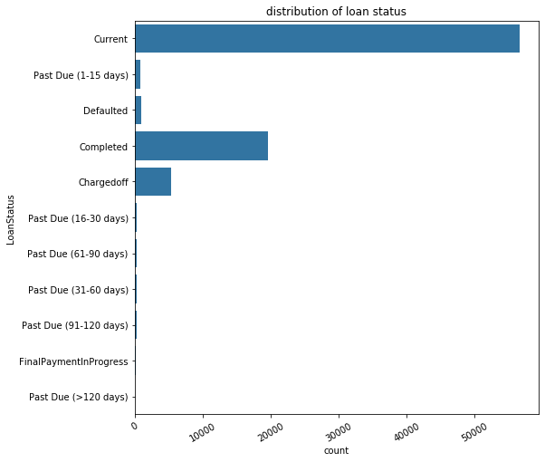

```python
 plt.subplots( figsize = [8,8])
sb.countplot(data=df,y='LoanStatus',color=sb.color_palette()[0] )
plt.xticks(rotation=30)
plt.title("distribution of loan status")
```

```python
df[df['LoanStatus']=='Completed'].count()[0]
```

```
19664
```

```python
df[df['LoanStatus']=='Current'].count()[0]
```

```
56576
```

```python
df[df['LoanStatus']=='Past Due (>120 days)'].count()[0]
```

```
16
```

```python
df[df['LoanStatus']=='Past Due (91-120 days)'].count()[0]
```

```
304
```

```python
df[df['LoanStatus']=='Past Due (31-60 days)'].count()[0]
```

```
363
```

```python
df[df['LoanStatus']=='Past Due (61-90 days)'].count()[0]
```

```
313
```

```python
df[df['LoanStatus']=='Past Due (16-30 days)'].count()[0]
```

```
265
```

we can consider the distribution as bimodal with two peaks at current and completed status

past due > 120 days here is considered to be a real outlier compared to the whole number of data but i won't remove it until further exploration as not sure whether to remove it or not I will check also the borrowerABR and borrowerrate for them

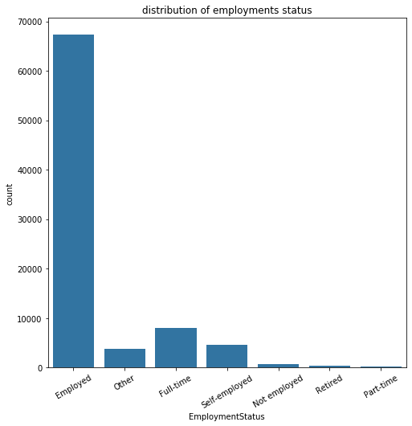

```python
#plotting the distribution of the emoployment status
plt.subplots( figsize = [8,8])
sb.countplot(data=df,x='EmploymentStatus',color=sb.color_palette()[0] )
plt.xticks(rotation=30)
plt.title('distribution of employments status')
```

> It seems that most of our data of loans referring that loans are asked and given for employed

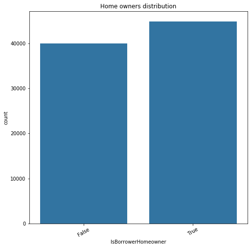

```python
plt.subplots( figsize = [8,8])
sb.countplot(data=df,x='IsBorrowerHomeowner',color=sb.color_palette()[0] )
plt.xticks(rotation=30)
plt.title('Home owners distribution')
```

```python
df.IsBorrowerHomeowner.value_counts()
```

```
True     44848
False    40005
Name: IsBorrowerHomeowner, dtype: int64
```

> number of people that are homeowners are greater than aren't, people who owns home are nearly 45000 and people doesn't own homes are 40000 , that difference gives an indication that won't play a impact factor in the borrowerRate

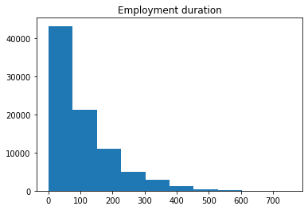

```python
plt.hist(data = df , x='EmploymentStatusDuration')
plt.title('Employment duration')
```

```
(0, 200)
```

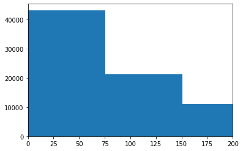

```python
plt.hist(data = df , x='EmploymentStatusDuration')
plt.xlim([0,200])
```

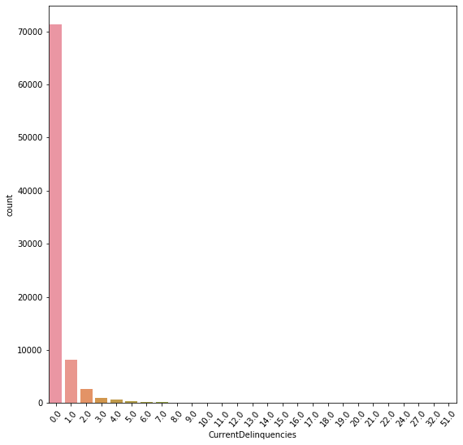

```python
plt.subplots( figsize = [9,9])

sb.countplot(data = df , x='CurrentDelinquencies')
#plt.xlim([0,8])
plt.xticks(rotation = 50)
```

> The distibution of current delinquencies is really right skewed that we can say we can neglect the values greater than 1, as most of accounts accumulate the first bar wich is zero tick

```python
df['CurrentDelinquencies'].astype(float).value_counts()
```

```
0.0     71252
1.0      8223
2.0      2631
3.0      1039
4.0       611
5.0       310
6.0       232
7.0       167
8.0       106
9.0        79
10.0       54
11.0       43
13.0       26
12.0       23
15.0       12
14.0       11
17.0        9
16.0        9
21.0        5
24.0        2
18.0        2
27.0        2
19.0        1
22.0        1
32.0        1
20.0        1
51.0        1
Name: CurrentDelinquencies, dtype: int64
```

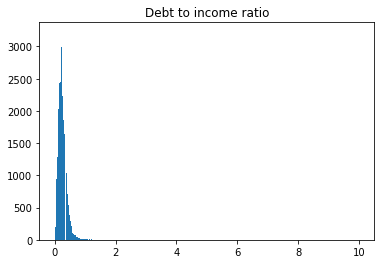

```python
bins = np.arange(0,df['DebtToIncomeRatio'].max(),0.01)
plt.hist(df['DebtToIncomeRatio'],bins=bins)
plt.title('Debt to income ratio')
```

> it appears like it is a right skewed not normal distribution but it seem that there are many outliers as the graph continues to 10 but we can't find the values, but we want to check if we drop them or not so we make a limitation on x axis to really see the shape

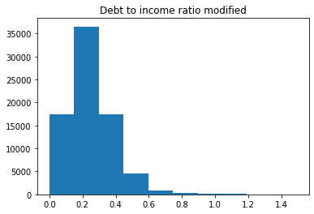

```python
hh = df[df['DebtToIncomeRatio']<1.5]
plt.hist(hh['DebtToIncomeRatio'])
plt.title('Debt to income ratio modified')
```

It seems that a low number people have a ratio larger than 1 which makes that whole data or nearly all have debt less than income which can be satsifying for the lenders, so the initial intuition that it won't play a role in the borrower rate I am going to investigate more seeing the correlation between them

```python
df[df['ProsperScore']>10].iloc[:,12:]
```

|  | EstimatedReturn | ProsperRating (numeric) | ProsperRating (Alpha) | ProsperScore | ListingCategory (numeric) | BorrowerState | Occupation | EmploymentStatus | EmploymentStatusDuration | IsBorrowerHomeowner | ... | LP_ServiceFees | LP_CollectionFees | LP_GrossPrincipalLoss | LP_NetPrincipalLoss | LP_NonPrincipalRecoverypayments | PercentFunded | Recommendations | InvestmentFromFriendsCount | InvestmentFromFriendsAmount | Investors |
| --- | --- | --- | --- | --- | --- | --- | --- | --- | --- | --- | --- | --- | --- | --- | --- | --- | --- | --- | --- | --- | --- |
| 9 | 0.04231 | 7.0 | AA | 11.0 | 7 | IL | Food Service | Employed | 269.0 | True | ... | -16.77 | 0.0 | 0.0 | 0.0 | 0.0 | 1.0 | 0 | 0 | 0.0 | 1 |
| 69 | 0.06499 | 6.0 | A | 11.0 | 1 | IL | Investor | Self-employed | 12.0 | True | ... | -7.15 | 0.0 | 0.0 | 0.0 | 0.0 | 1.0 | 0 | 0 | 0.0 | 1 |
| 158 | 0.04929 | 7.0 | AA | 11.0 | 6 | OR | Tradesman - Mechanic | Employed | 22.0 | False | ... | -1.96 | 0.0 | 0.0 | 0.0 | 0.0 | 1.0 | 0 | 0 | 0.0 | 1 |
| 224 | 0.06388 | 6.0 | A | 11.0 | 1 | WI | Sales - Commission | Employed | 114.0 | True | ... | -25.48 | 0.0 | 0.0 | 0.0 | 0.0 | 1.0 | 0 | 0 | 0.0 | 1 |
| 236 | 0.04261 | 7.0 | AA | 11.0 | 1 | OR | Tradesman - Mechanic | Employed | 105.0 | True | ... | -22.10 | 0.0 | 0.0 | 0.0 | 0.0 | 1.0 | 0 | 0 | 0.0 | 198 |
| ... | ... | ... | ... | ... | ... | ... | ... | ... | ... | ... | ... | ... | ... | ... | ... | ... | ... | ... | ... | ... | ... |
| 113762 | 0.06499 | 6.0 | A | 11.0 | 20 | NY | Other | Employed | 41.0 | True | ... | -56.88 | 0.0 | 0.0 | 0.0 | 0.0 | 1.0 | 0 | 0 | 0.0 | 149 |
| 113784 | 0.06153 | 6.0 | A | 11.0 | 1 | CA | Other | Employed | 158.0 | True | ... | -36.89 | 0.0 | 0.0 | 0.0 | 0.0 | 1.0 | 0 | 0 | 0.0 | 1 |
| 113855 | 0.06706 | 6.0 | A | 11.0 | 3 | NY | Food Service Management | Full-time | 89.0 | False | ... | 0.00 | 0.0 | 0.0 | 0.0 | 0.0 | 1.0 | 0 | 0 | 0.0 | 143 |
| 113881 | 0.08524 | 4.0 | C | 11.0 | 7 | CO | Professional | Employed | 37.0 | True | ... | -64.44 | 0.0 | 0.0 | 0.0 | 0.0 | 1.0 | 0 | 0 | 0.0 | 1 |
| 113912 | 0.04260 | 7.0 | AA | 11.0 | 2 | MN | Scientist | Employed | 102.0 | False | ... | -7.15 | 0.0 | 0.0 | 0.0 | 0.0 | 1.0 | 0 | 0 | 0.0 | 1 |

1456 rows × 69 columns

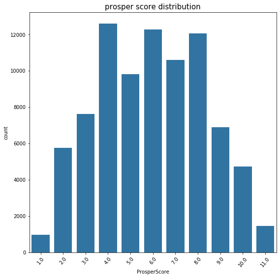

```python
plt.subplots( figsize = [9,9])

sb.countplot(data = df , x='ProsperScore',color=sb.color_palette()[0])
#plt.xlim([0,8])

plt.xticks(rotation = 50)
plt.title('prosper score distribution',size=15)
```

```python
df['Term'].value_counts()
```

```
36    58695
60    24545
12     1613
Name: Term, dtype: int64
```

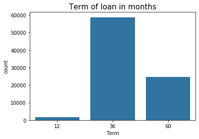

```python
sb.countplot(data = df , x='Term',color=sb.color_palette()[0])
plt.title('Term of loan in months',size=15)
```

It is clear that loans are 3 categoris one year , 3 years , 5 years but our loans are mainly concentrated at 3 years , I should investigate more why this is the case, is 3 years provide a borrowerrates more lower than one year ?

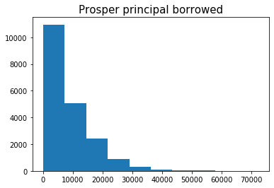

```python
plt.hist(df['ProsperPrincipalBorrowed'])
plt.title('Prosper principal borrowed',size=15)
```

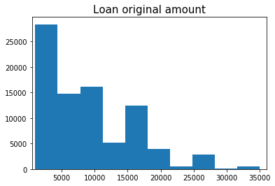

```python
plt.hist(df['LoanOriginalAmount'])
plt.xlim([500,36000])
plt.title('Loan original amount',size=15)
```

> Loan original amount follows a right skewed but not a uniform or perfect shape as the value at 10000 is higher than 5000 so we can't say it follows right skewed

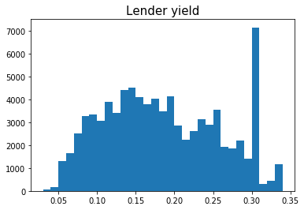

```python
bins = np.arange(df.LenderYield.min(),df.LenderYield.max()+0.001,0.01)
plt.hist(df['LenderYield'],bins =bins)
plt.title('Lender yield',size=15)
```

```python
df['CurrentlyInGroup'].value_counts()
```

```
False    82607
True      2246
Name: CurrentlyInGroup, dtype: int64
```

```python
df['TotalProsperLoans'].value_counts()
```

```
1.0    13409
2.0     4396
3.0     1436
4.0      415
5.0      102
6.0       29
7.0        8
0.0        1
8.0        1
Name: TotalProsperLoans, dtype: int64
```

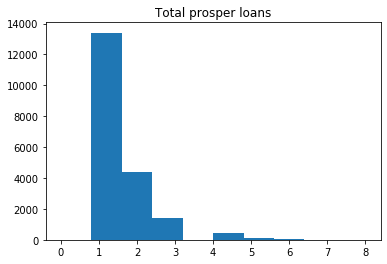

```python
plt.hist(df['TotalProsperLoans'])
plt.title('Total prosper loans')
```

> It seems that most of pople are asking for their first loan, so it isn't probable that the number of loans affect the borrower rate due to difference between the numbers between 1 ,2 , 3 in total prosper loans distribution

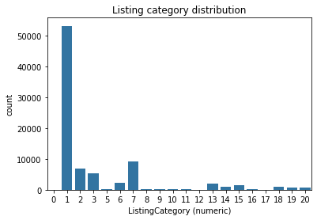

```python
sb.countplot(data = df , x='ListingCategory (numeric)',color = sb.color_palette()[0])
plt.title('Listing category distribution')
```

> Listing category numebrs here represent the reason for the loan , we see the numbers at 1 is the main point which represnt debt consolidation , 2 represnt home improvement , 3 represent business , 7 represent other but we try to remove the outliers so to look deeper into the curve

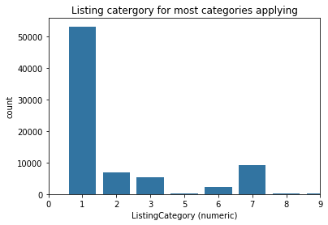

```python
sb.countplot(data = df , x='ListingCategory (numeric)',color = sb.color_palette()[0])
plt.xlim([0,8])
plt.title('Listing catergory for most categories applying')
```

> When focusing on the curve from 1 to 8 , it seems like right skewed with bulk amount at 1 which means debt consolidation , I wll investigate more to see is different ctegory gives diffferent borrower rate ?

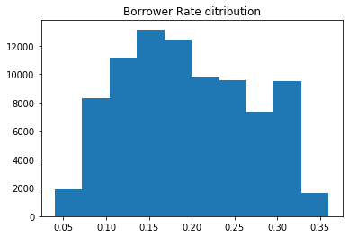

```python
plt.hist(df.BorrowerRate)
plt.title('Borrower Rate ditribution')
```

it seems that the borrower rate covers a wide distribution but is that shape similar to the lender yield we saw before ?

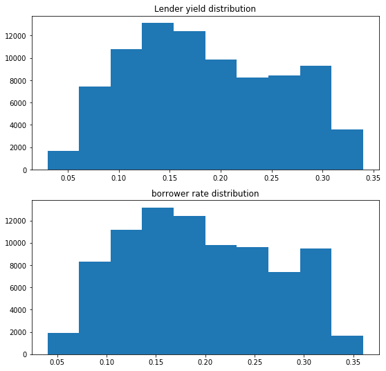

```python
fig, ax = plt.subplots(nrows=2, figsize = [9,9])
default_color = sb.color_palette()[0]
ax[0].hist(data = df, x = 'LenderYield', color = default_color)
ax[0].set_title('Lender yield distribution')
ax[1].hist(data = df, x = 'BorrowerRate', color = default_color)
ax[1].set_title('borrower rate distribution')
```

they are nearly identical so we expect to get a high correlation when discussing the bivariate relation between them

### Discuss the distribution(s) of your variable(s) of interest. Were there any unusual points? Did you need to perform any transformations?

> Some columns show that there is a possiblity of outliers but apart of that there seems no need to perform a transformation for a certain column or no need to make a logarithmic transformation , the column variable of interest borrower rate , its distribution shows a stange behavior not a normal disribution it is a little near right skewed

### Of the features you investigated, were there any unusual distributions? Did you perform any operations on the data to tidy, adjust, or change the form of the data? If so, why did you do this?

> I didn't find any unsual distribution except listing category column it is form of spikes , also totalprosper loans distribution,also the term distribution (column which represent the loan term whether year or 3 or 5 years) from my point of view , regarding the point of operation on data to make it tidy I removed the data before 2009 as many columns said that they are collected beginning at the year 2009

## Bivariate Exploration

> In this section, investigate relationships between pairs of variables in your data. Make sure the variables that you cover here have been introduced in some fashion in the previous section (univariate exploration).

```python
numeric_vars = ['DebtToIncomeRatio', 'CurrentDelinquencies', 'EmploymentStatusDuration','CurrentCreditLines','EstimatedEffectiveYield','OpenCreditLines','LoanOriginalAmount','LenderYield','ProsperPrincipalBorrowed','BorrowerRate','ListingCategory (numeric)']
categoric_vars = ['IsBorrowerHomeowner', 'LoanStatus','EmploymentStatus','ProsperScore','Term','BorrowerState','CurrentlyInGroup']
```

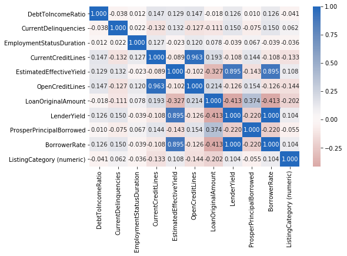

```python
plt.figure(figsize = [8, 5])
sb.heatmap(df[numeric_vars].corr(), annot = True, fmt = '.3f',
           cmap = 'vlag_r', center = 0)
plt.show()
```

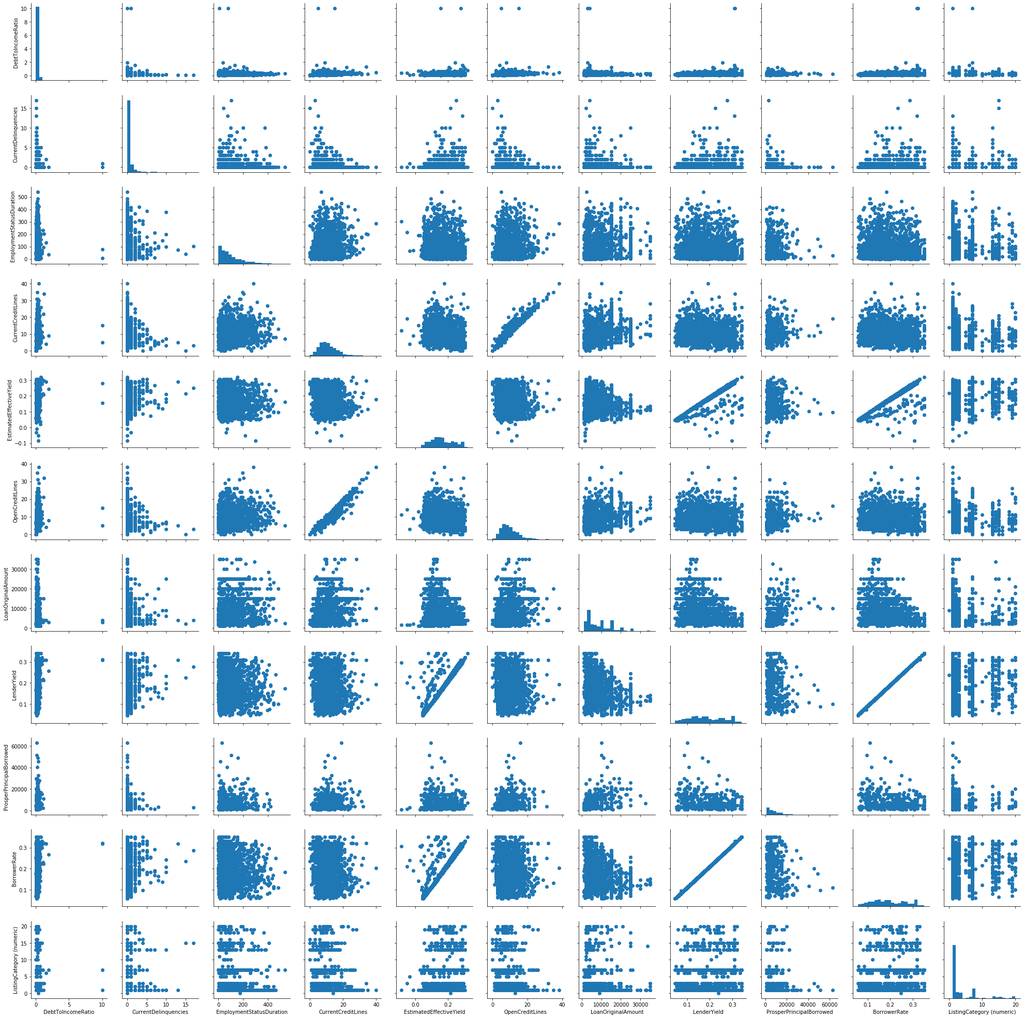

```python
samples = np.random.choice(df.shape[0], 2000, replace = False)
df_sample = df.loc[samples,:]

g = sb.PairGrid(data = df_sample, vars = numeric_vars)
g = g.map_diag(plt.hist, bins = 20);
g.map_offdiag(plt.scatter)
```

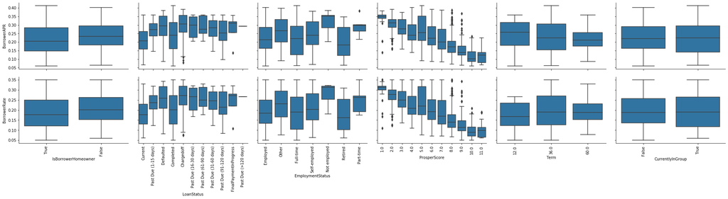

```python
samples = np.random.choice(df.shape[0], 5000, replace = False)
df_samp = df.loc[samples,:]

def boxgrid(x, y, **kwargs):
    """ Quick hack for creating box plots with seaborn's PairGrid. """
    default_color = sb.color_palette()[0]
    sb.boxplot(x, y, color = default_color)
    plt.xticks(rotation = 90)


plt.figure(figsize = [15, 15])
g = sb.PairGrid(data = df_samp, y_vars = ['BorrowerAPR', 'BorrowerRate'], x_vars = ['IsBorrowerHomeowner', 'LoanStatus','EmploymentStatus','ProsperScore','Term','CurrentlyInGroup'],
                size = 3, aspect = 1.5)
g.map(boxgrid)
plt.show();
```

> In the boxplot of loan status versus borrower rate it is obvious that defaulated,and all the past due had a higher borrower rate on average , and the box plot of borrowerRate versus isborrowerhome owner or not , if borrower doesn't have house it has a higher borrower rate on average

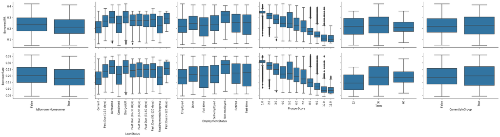

```python
#samples = np.random.choice(df.shape[0], 5000, replace = False)
#df_samp = df.loc[samples,:]

def boxgrid(x, y, **kwargs):
    """ Quick hack for creating box plots with seaborn's PairGrid. """
    default_color = sb.color_palette()[0]
    sb.boxplot(x, y, color = default_color)
    plt.xticks(rotation = 90)


plt.figure(figsize = [15, 15])
g = sb.PairGrid(data = df, y_vars = ['BorrowerAPR', 'BorrowerRate'], x_vars = ['IsBorrowerHomeowner', 'LoanStatus','EmploymentStatus','ProsperScore','Term','CurrentlyInGroup'],
                size = 3, aspect = 1.5)
g.map(boxgrid)
plt.show();
```

> plotting the whole data instead of a sample to get a full intuition about our data, we took an idea that if borrower owns his home or not that will affect the borrower rate and employment status also affects the borrower rate, and obviously the prosperscore has a significant impact on the borrowing rate